# Выбор локации для скважины

# Table of Contents

## Описание проекта

Допустим, вы работаете в добывающей компании «ГлавРосГосНефть». Нужно решить, где бурить новую скважину.

Вам предоставлены пробы нефти в трёх регионах: в каждом 10 000 месторождений, где измерили качество нефти и объём её запасов. Постройте модель машинного обучения, которая поможет определить регион, где добыча принесёт наибольшую прибыль. Проанализируйте возможную прибыль и риски техникой *Bootstrap.*

Шаги для выбора локации:

- В избранном регионе ищут месторождения, для каждого определяют значения признаков;
- Строят модель и оценивают объём запасов;
- Выбирают месторождения с самым высокими оценками значений. Количество месторождений зависит от бюджета компании и стоимости разработки одной скважины;
- Прибыль равна суммарной прибыли отобранных месторождений.

## План работы

1. Загрузим и подготовим данные. Поясним порядок действий.
2. Обучим и проверим модель для каждого региона:  
   2.1. Разобъем данные на обучающую и валидационную выборки в соотношении 75:25.  
   2.2. Обучим модель и сделаем предсказания на валидационной выборке.  
   2.3. Сохраним предсказания и правильные ответы на валидационной выборке.  
   2.4. Напечатаем на экране средний запас предсказанного сырья и RMSE модели.  
   2.5. Проанализируем результаты.
3. Подготовимся к расчёту прибыли:  
   3.1. Все ключевые значения для расчётов сохраним в отдельных переменных.  
   3.2. Рассчитаем достаточный объём сырья для безубыточной разработки новой скважины. Сравним полученный объём сырья со средним запасом в каждом регионе.  
   3.3. Напишем выводы по этапу подготовки расчёта прибыли.
4. Напишем функцию для расчёта прибыли по выбранным скважинам и предсказаниям модели:  
   4.1. Выберем скважины с максимальными значениями предсказаний.  
   4.2. Просуммируем целевое значение объёма сырья, соответствующее этим предсказаниям.  
   4.3. Рассчитаем прибыль для полученного объёма сырья.
5. Посчитаем риски и прибыль для каждого региона:  
   5.1. Применим технику Bootstrap с 1000 выборок, чтобы найти распределение прибыли.  
   5.2. Найдем среднюю прибыль, 95%-й доверительный интервал и риск убытков. Убыток — это отрицательная прибыль.  
   5.3. Напишем выводы: предложим регион для разработки скважин и обоснуем выбор.

## Описание данных

- `id` — уникальный идентификатор скважины
- `f0`, `f1`, `f2` — три признака точек (неважно, что они означают, но сами признаки значимы)
- `product` — объём запасов в скважине (тыс. баррелей)

**Данные геологоразведки трёх регионов находятся в файлах:**

- `/datasets/geo_data_0.csv`
- `/datasets/geo_data_1.csv`
- `/datasets/geo_data_2.csv`

## Условия задачи

- Для обучения модели подходит только линейная регрессия (остальные — недостаточно предсказуемые)
- При разведке региона исследуют 500 точек, из которых с помощью машинного обучения выбирают 200 лучших для разработки
- Бюджет на разработку скважин в регионе — 10 млрд рублей
- При нынешних ценах один баррель сырья приносит 450 рублей дохода. Доход с каждой единицы продукта составляет 450 тыс. рублей, поскольку объём указан в тысячах баррелей
- После оценки рисков нужно оставить лишь те регионы, в которых вероятность убытков меньше 2.5%. Среди них выбирают регион с наибольшей средней прибылью

Данные синтетические: детали контрактов и характеристики месторождений не разглашаются.

```python
!pip -q install phik
!pip -q install -U scikit-learn
!pip -q install shap
```

```python
import pandas as pd
import matplotlib.pyplot as plt
import numpy as np
import re
import seaborn as sns
import shap

import warnings
warnings.simplefilter(action='ignore', category=FutureWarning)

from IPython.display import display

from phik import phik_matrix
from sklearn.impute import SimpleImputer
from sklearn.pipeline import Pipeline
from sklearn.compose import ColumnTransformer
from sklearn.preprocessing import (
    StandardScaler, MinMaxScaler
)
from sklearn.linear_model import LinearRegression, Lasso, Ridge
from sklearn.model_selection import train_test_split, GridSearchCV
from sklearn.metrics import mean_squared_error
from scipy.stats import shapiro
```

```python
# Настройки вывода графиков
plt.rcParams["axes.titlesize"] = 16  # Размер шрифта
plt.rcParams["axes.titleweight"] = "bold"  # Толщина шрифта

# Константы
RANDOM_STATE = 42
TEST_SIZE = 0.25
TERM_SIZE = 180
```

## Загрузка данных

```python
try:
    geo_data_0 = pd.read_csv("C:\\Data-science\\ds_csv\\geo_data_0.csv")
    geo_data_1 = pd.read_csv("C:\\Data-science\\ds_csv\\geo_data_1.csv")
    geo_data_2 = pd.read_csv("C:\\Data-science\\ds_csv\\geo_data_2.csv")
except:
    try:
        geo_data_0 = pd.read_csv('/datasets/geo_data_0.csv')
        geo_data_1 = pd.read_csv('/datasets/geo_data_1.csv')
        geo_data_2 = pd.read_csv('/datasets/geo_data_2.csv')
    except:
        raise FileNotFoundError
```

### Изучение загруженных датасетов

```python
# Создаем словарь, чтобы перебрать все импортируемые датафреймы
dataframes = {
    "geo_data_0": geo_data_0,
    "geo_data_1": geo_data_1,
    "geo_data_2": geo_data_2,
}


# Цикл по каждому DataFrame с выводом имени, информации и первых строк
for name, data in dataframes.items():
    print(f'\033[1mНаименование анализируемого датафрейма:\033[0m {name}')
    print()
    data.info()  # Выводим информацию о DataFrame
    display(data.head(5))  # Отображаем первые 5 строк
    print('=' * TERM_SIZE)  # Линия-разделитель по ширине терминала
```

```
Наименование анализируемого датафрейма: geo_data_0

<class 'pandas.core.frame.DataFrame'>
RangeIndex: 100000 entries, 0 to 99999
Data columns (total 5 columns):
 #   Column   Non-Null Count   Dtype
---  ------   --------------   -----
 0   id       100000 non-null  object
 1   f0       100000 non-null  float64
 2   f1       100000 non-null  float64
 3   f2       100000 non-null  float64
 4   product  100000 non-null  float64
dtypes: float64(4), object(1)
memory usage: 3.8+ MB
```

|  | id | f0 | f1 | f2 | product |
| --- | --- | --- | --- | --- | --- |
| 0 | txEyH | 0.705745 | -0.497823 | 1.221170 | 105.280062 |
| 1 | 2acmU | 1.334711 | -0.340164 | 4.365080 | 73.037750 |
| 2 | 409Wp | 1.022732 | 0.151990 | 1.419926 | 85.265647 |
| 3 | iJLyR | -0.032172 | 0.139033 | 2.978566 | 168.620776 |
| 4 | Xdl7t | 1.988431 | 0.155413 | 4.751769 | 154.036647 |

```
====================================================================================================================================================================================
Наименование анализируемого датафрейма: geo_data_1

<class 'pandas.core.frame.DataFrame'>
RangeIndex: 100000 entries, 0 to 99999
Data columns (total 5 columns):
 #   Column   Non-Null Count   Dtype
---  ------   --------------   -----
 0   id       100000 non-null  object
 1   f0       100000 non-null  float64
 2   f1       100000 non-null  float64
 3   f2       100000 non-null  float64
 4   product  100000 non-null  float64
dtypes: float64(4), object(1)
memory usage: 3.8+ MB
```

|  | id | f0 | f1 | f2 | product |
| --- | --- | --- | --- | --- | --- |
| 0 | kBEdx | -15.001348 | -8.276000 | -0.005876 | 3.179103 |
| 1 | 62mP7 | 14.272088 | -3.475083 | 0.999183 | 26.953261 |
| 2 | vyE1P | 6.263187 | -5.948386 | 5.001160 | 134.766305 |
| 3 | KcrkZ | -13.081196 | -11.506057 | 4.999415 | 137.945408 |
| 4 | AHL4O | 12.702195 | -8.147433 | 5.004363 | 134.766305 |

```
====================================================================================================================================================================================
Наименование анализируемого датафрейма: geo_data_2

<class 'pandas.core.frame.DataFrame'>
RangeIndex: 100000 entries, 0 to 99999
Data columns (total 5 columns):
 #   Column   Non-Null Count   Dtype
---  ------   --------------   -----
 0   id       100000 non-null  object
 1   f0       100000 non-null  float64
 2   f1       100000 non-null  float64
 3   f2       100000 non-null  float64
 4   product  100000 non-null  float64
dtypes: float64(4), object(1)
memory usage: 3.8+ MB
```

|  | id | f0 | f1 | f2 | product |
| --- | --- | --- | --- | --- | --- |
| 0 | fwXo0 | -1.146987 | 0.963328 | -0.828965 | 27.758673 |
| 1 | WJtFt | 0.262778 | 0.269839 | -2.530187 | 56.069697 |
| 2 | ovLUW | 0.194587 | 0.289035 | -5.586433 | 62.871910 |
| 3 | q6cA6 | 2.236060 | -0.553760 | 0.930038 | 114.572842 |
| 4 | WPMUX | -0.515993 | 1.716266 | 5.899011 | 149.600746 |

**Вывод по предварительному анализу:**

В ходе предварительного анализа данных было выявлено:

- В датафреймах отсвутствуют пропуски;
- Название столбцов датафреймов соответствуют snake_case;
- Нет ошибок в типах данных в датафреймах;
- Была получена общая информация о датафреймах.

## Предобработка данных

### Проверка датафреймов на дубликаты

**Проверка на явные дубликаты**

```python
for name, data in dataframes.items():
    print(f"Явных дубликатов в датасете {name} - {data.duplicated().sum()}: "
          if data.duplicated().sum() > 0 else f"Явных дубликатов в датасете {name} - НЕТ")
```

```
Явных дубликатов в датасете geo_data_0 - НЕТ
Явных дубликатов в датасете geo_data_1 - НЕТ
Явных дубликатов в датасете geo_data_2 - НЕТ
```

**Проверка на неявные дубликаты**

```python
for name, data in dataframes.items():
    print(f"Дубликатов в столбце 'id' датасета {name} - {data['id'].duplicated().sum()}: "
          if data['id'].duplicated().sum() > 0 else f"Явных дубликатов в датасете {name} - НЕТ")
```

```
Дубликатов в столбце 'id' датасета geo_data_0 - 10:
Дубликатов в столбце 'id' датасета geo_data_1 - 4:
Дубликатов в столбце 'id' датасета geo_data_2 - 4:
```

Найдем все дубликаты id (скважин) и выведим информацию о них

```python
for name, data in dataframes.items():
    print(f"Измененные дубликаты id в датафрейме {name}")
    duplicates_sorted = data[data['id'].duplicated(keep=False)].sort_values('id', ascending=False)
    # Сохраняем индексы строк с дубликатами
    duplicate_rows_idx = data[data['id'].duplicated(keep=False)].sort_values('id', ascending=False).index
    # Добавляем к дубликатам суффиксы _1, _2 и т.д.
    data['id'] = data['id'] + data.groupby('id').cumcount().add(1).apply(lambda x: f"_{x}" if x > 0 else "")
    # Проверка
    display(data.loc[duplicate_rows_idx])
```

```
Измененные дубликаты id в датафрейме geo_data_0
```

|  | id | f0 | f1 | f2 | product |
| --- | --- | --- | --- | --- | --- |
| 90815 | fiKDv_2 | 0.049883 | 0.841313 | 6.394613 | 137.346586 |
| 16633 | fiKDv_1 | 0.157341 | 1.028359 | 5.585586 | 95.817889 |
| 41724 | bxg6G_2 | -0.823752 | 0.546319 | 3.630479 | 93.007798 |
| 1364 | bxg6G_1 | 0.411645 | 0.856830 | -3.653440 | 73.604260 |
| 97785 | bsk9y_2 | 0.378429 | 0.005837 | 0.160827 | 160.637302 |
| 89582 | bsk9y_1 | 0.398908 | -0.400253 | 10.122376 | 163.433078 |
| 92341 | TtcGQ_2 | 0.110711 | 1.022689 | 0.911381 | 101.318008 |
| 60140 | TtcGQ_1 | 0.569276 | -0.104876 | 6.440215 | 85.350186 |
| 21426 | Tdehs_1 | 0.829407 | 0.298807 | -0.049563 | 96.035308 |
| 75715 | Tdehs_2 | 0.112079 | 0.430296 | 3.218993 | 60.964018 |
| 63593 | QcMuo_2 | 0.635635 | -0.473422 | 0.862670 | 64.578675 |
| 1949 | QcMuo_1 | 0.506563 | -0.323775 | -2.215583 | 75.496502 |
| 7530 | HZww2_2 | 1.061194 | -0.373969 | 10.430210 | 158.828695 |
| 931 | HZww2_1 | 0.755284 | 0.368511 | 1.863211 | 30.681774 |
| 42529 | AGS9W_1 | 1.454747 | -0.479651 | 0.683380 | 126.370504 |
| 69163 | AGS9W_2 | -0.933795 | 0.116194 | -3.655896 | 19.230453 |
| 51970 | A5aEY_2 | -0.180335 | 0.935548 | -2.094773 | 33.020205 |
| 3389 | A5aEY_1 | -0.039949 | 0.156872 | 0.209861 | 89.249364 |
| 64022 | 74z30_1 | 0.741456 | 0.459229 | 5.153109 | 140.771492 |
| 66136 | 74z30_2 | 1.084962 | -0.312358 | 6.990771 | 127.643327 |

```
Измененные дубликаты id в датафрейме geo_data_1
```

|  | id | f0 | f1 | f2 | product |
| --- | --- | --- | --- | --- | --- |
| 47591 | wt4Uk_1 | -9.091098 | -8.109279 | -0.002314 | 3.179103 |
| 82873 | wt4Uk_2 | 10.259972 | -9.376355 | 4.994297 | 134.766305 |
| 2721 | bfPNe_1 | -9.494442 | -5.463692 | 4.006042 | 110.992147 |
| 82178 | bfPNe_2 | -6.202799 | -4.820045 | 2.995107 | 84.038886 |
| 1305 | LHZR0_1 | 11.170835 | -1.945066 | 3.002872 | 80.859783 |
| 41906 | LHZR0_2 | -8.989672 | -4.286607 | 2.009139 | 57.085625 |
| 5849 | 5ltQ6_1 | -3.435401 | -12.296043 | 1.999796 | 57.085625 |
| 84461 | 5ltQ6_2 | 18.213839 | 2.191999 | 3.993869 | 107.813044 |

```
Измененные дубликаты id в датафрейме geo_data_2
```

|  | id | f0 | f1 | f2 | product |
| --- | --- | --- | --- | --- | --- |
| 28039 | xCHr8_1 | 1.633027 | 0.368135 | -2.378367 | 6.120525 |
| 43233 | xCHr8_2 | -0.847066 | 2.101796 | 5.597130 | 184.388641 |
| 44378 | Vcm5J_1 | -1.229484 | -2.439204 | 1.222909 | 137.968290 |
| 95090 | Vcm5J_2 | 2.587702 | 1.986875 | 2.482245 | 92.327572 |
| 11449 | VF7Jo_1 | 2.122656 | -0.858275 | 5.746001 | 181.716817 |
| 49564 | VF7Jo_2 | -0.883115 | 0.560537 | 0.723601 | 136.233420 |
| 45404 | KUPhW_1 | 0.231846 | -1.698941 | 4.990775 | 11.716299 |
| 55967 | KUPhW_2 | 1.211150 | 3.176408 | 5.543540 | 132.831802 |

**Вывод по предобработке данных:**

В ходе предобработке данных было выявлено:

- Была проведена работа с дубликатами в ходе которой было обнаружено, что из одной скважины (id) может присутствовать несколько записей, данные скважины (id) были обозначены для упрощения взаимодействия с данными

## Исследовательский анализ данных

### Функции для исследовательского анализа данных

```python
def show_num_variable(df, column, target=None):
    '''
    Функция отображения гистограммы распределения
    и диаграммы размаха для определенного столбца датафрейма
    с учетом принадлежности данного столбца к разным значениям
    переменной target.

    Параметры:
    - df: pandas.DataFrame, входной датафрейм
    - column: str, столбец для анализа
    - target: str или None, столбец для группировки (по умолчанию None)
    '''
    sns.set()
    f, axes = plt.subplots(1, 2, figsize=(16, 6))

    # Гистограмма
    axes[0].set_title(f'Гистограмма для {column}', fontsize=16)
    axes[0].set_ylabel('Количество', fontsize=14)
    if target:
        sns.histplot(data=df, bins=20, kde=True, ax=axes[0], hue=target, x=column)
    else:
        sns.histplot(data=df, bins=20, kde=True, ax=axes[0], x=column)

    # Диаграмма размаха
    axes[1].set_title(f'Диаграмма размаха для {column}', fontsize=16)
    if target:
        sns.boxplot(data=df, ax=axes[1], x=target, y=column)
    else:
        sns.boxplot(data=df, ax=axes[1], y=column, orient='v')
    axes[1].set_ylabel(column, fontsize=14)

    plt.tight_layout()
    plt.show()
```

```python
def show_outliers(data, df_name="DataFrame"):
    '''
    Функция для поиска и анализа выбросов в числовых столбцах DataFrame.

    Что делает:
    - Находит выбросы по каждому числовому столбцу с помощью метода IQR (межквартильный размах).
    - Определяет строки, в которых есть хотя бы один выброс.
    - Считает и выводит общий процент таких строк от всего датафрейма.

    Параметры:
    - data: pandas.DataFrame — входной датафрейм с данными.

    Результат:
    - Печатает процент строк с выбросами.'
    '''
    # Формирование списка столбцов с количественными признаками
    num_variables_col = data.select_dtypes(include=['number']).columns.to_list()

    # Создаем маску для строк с выбросами
    outliers_mask = pd.DataFrame(False, index=data.index, columns=num_variables_col)

    # Проходим по каждому числовому столбцу и находим выбросы
    for col in num_variables_col:
        Q1 = data[col].quantile(0.25)
        Q3 = data[col].quantile(0.75)
        IQR = Q3 - Q1
        lower_bound = Q1 - 1.5 * IQR
        upper_bound = Q3 + 1.5 * IQR

        # Отмечаем строки, где значения выходят за границы
        outliers_mask[col] = (data[col] < lower_bound) | (data[col] > upper_bound)

    # Найдем строки с хотя бы одним выбросом
    rows_with_outliers = outliers_mask.any(axis=1)

    # Считаем процент таких строк
    total_outliers_percent = (rows_with_outliers.sum() / len(data)) * 100

    result = (
        f"Датафрейм: {df_name}\n\n"
        f"Общий процент выбросов по строкам: {total_outliers_percent:.2f}%\n"
        f"Общее количество таких строк: {rows_with_outliers.sum()}\n"
    )

    return result
```

### Статистический анализ

**Иследования данных датафрейма geo_data_0**

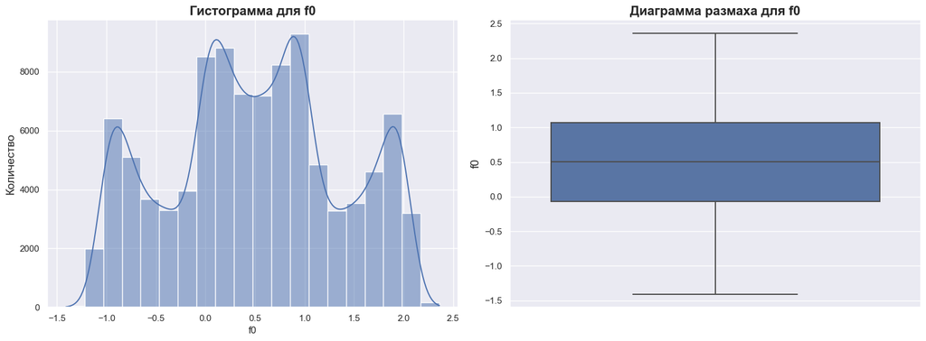

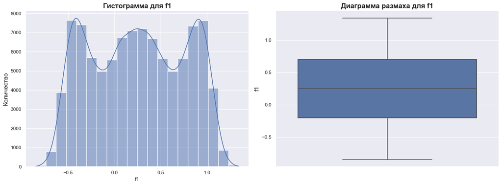

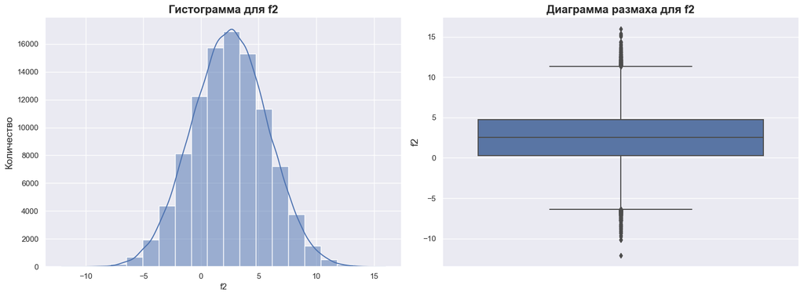

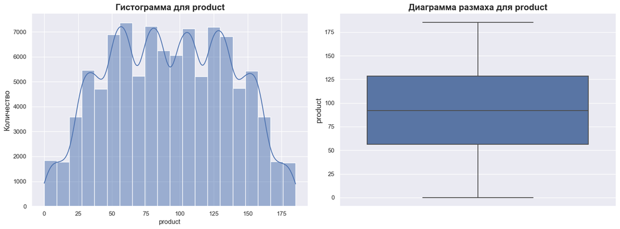

|  | f0 | f1 | f2 | product |
| --- | --- | --- | --- | --- |
| count | 100000.000000 | 100000.000000 | 100000.000000 | 100000.000000 |
| mean | 0.500419 | 0.250143 | 2.502647 | 92.500000 |
| std | 0.871832 | 0.504433 | 3.248248 | 44.288691 |
| min | -1.408605 | -0.848218 | -12.088328 | 0.000000 |
| 25% | -0.072580 | -0.200881 | 0.287748 | 56.497507 |
| 50% | 0.502360 | 0.250252 | 2.515969 | 91.849972 |
| 75% | 1.073581 | 0.700646 | 4.715088 | 128.564089 |
| max | 2.362331 | 1.343769 | 16.003790 | 185.364347 |

```python
# Формирование списка столбцов с количественными признаками
num_variables_col_0 = geo_data_0.select_dtypes(include=['number']).columns.to_list()

# Вывод графиков для датафрейма geo_data_0
for col in num_variables_col_0:
    show_num_variable(geo_data_0, col)

    print('=' * TERM_SIZE)

geo_data_0.describe()
```

Анализ данных месторождения в Регионе 0 датафрейма `geo_data_0`:

- Параметр `f0` имеет симметричное распределение относительно среднего, mean ~ 0.5 и median ~ 0.502;
- Параметр `f1` имеет симметричное распределение относительно среднего, mean ~ 0.25 и median ~ 0.25;
- Параметр `f2` имеет распределение близкое к нормальному, в нем присутствуют выбросы. Mean ~ 2.5 и median ~ 2.52;
- Параметр `product` объем запасов в скважине имеет симметричное распределение относительно среднего, mean ~ 92.5 и median ~ 91.84.

**Иследования данных датафрейма geo_data_1**

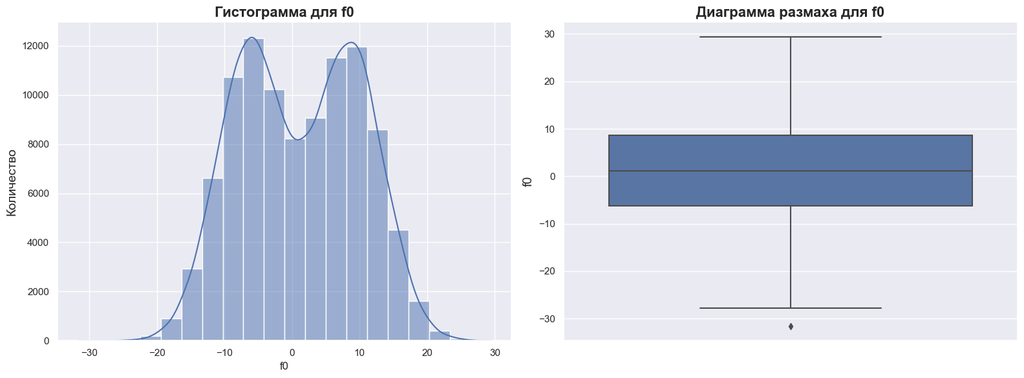

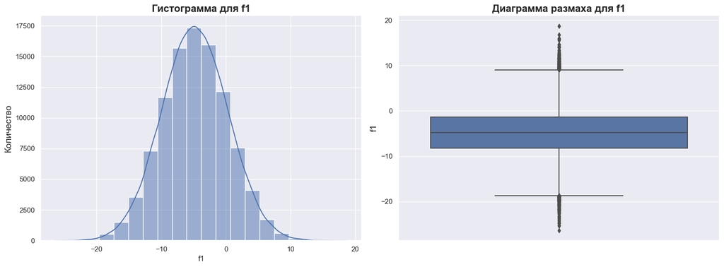

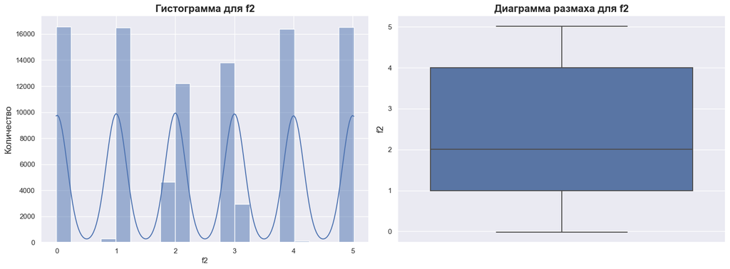

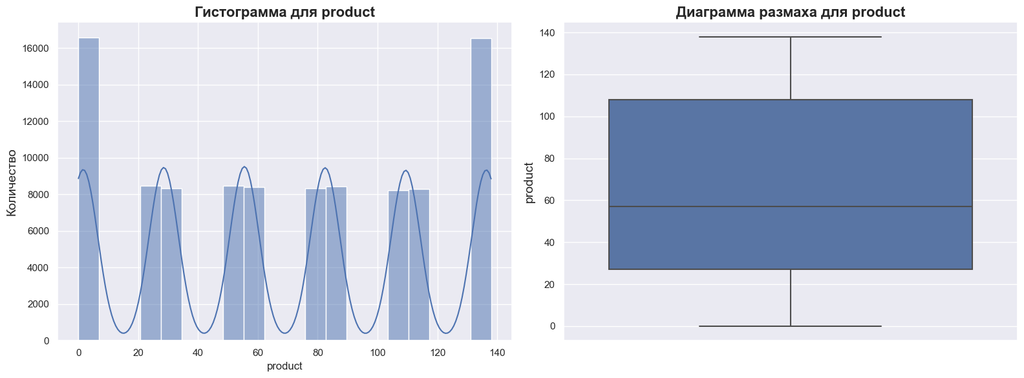

|  | f0 | f1 | f2 | product |
| --- | --- | --- | --- | --- |
| count | 100000.000000 | 100000.000000 | 100000.000000 | 100000.000000 |
| mean | 1.141296 | -4.796579 | 2.494541 | 68.825000 |
| std | 8.965932 | 5.119872 | 1.703572 | 45.944423 |
| min | -31.609576 | -26.358598 | -0.018144 | 0.000000 |
| 25% | -6.298551 | -8.267985 | 1.000021 | 26.953261 |
| 50% | 1.153055 | -4.813172 | 2.011479 | 57.085625 |
| 75% | 8.621015 | -1.332816 | 3.999904 | 107.813044 |
| max | 29.421755 | 18.734063 | 5.019721 | 137.945408 |

```python
# Формирование списка столбцов с количественными признаками
num_variables_col_1 = geo_data_1.select_dtypes(include=['number']).columns.to_list()

# Вывод графиков для датафрейма geo_data_1
for col in num_variables_col_1:
    show_num_variable(geo_data_1, col)

    print('=' * TERM_SIZE)

geo_data_1.describe()
```

Распределение параметров `f2` и `product` выглядят как категориальные, проверим данный факт посчитав количество уникальных значений для них

```python
display(f"Количество уникальных значений для столбца f2 {geo_data_1['f2'].unique().__len__()} - общее количество значений {geo_data_1['f2'].__len__()}")
f"Количество уникальных значений для столбца product {geo_data_1['product'].unique().__len__()} - общее количество значений {geo_data_1['product'].__len__()}"
```

```
'Количество уникальных значений для столбца f2 100000 - общее количество значений 100000'
```

```
'Количество уникальных значений для столбца product 12 - общее количество значений 100000'
```

Предположение с параметром `f2` не подтвердилось, количество уникальных значений совпадаеет у общим количеством столбцов, а для параметра `product` (объем запасов в скважине) наблюдается сильное различие количества уникальных значений (12) по отношению к общему числу записей.

**Иследования данных датафрейма geo_data_2**

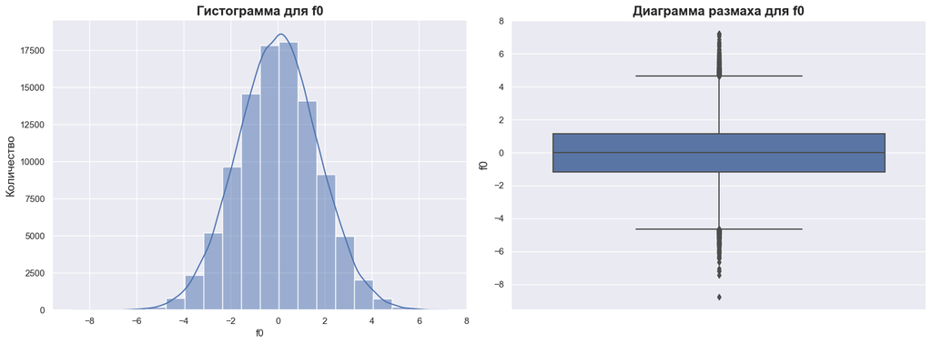

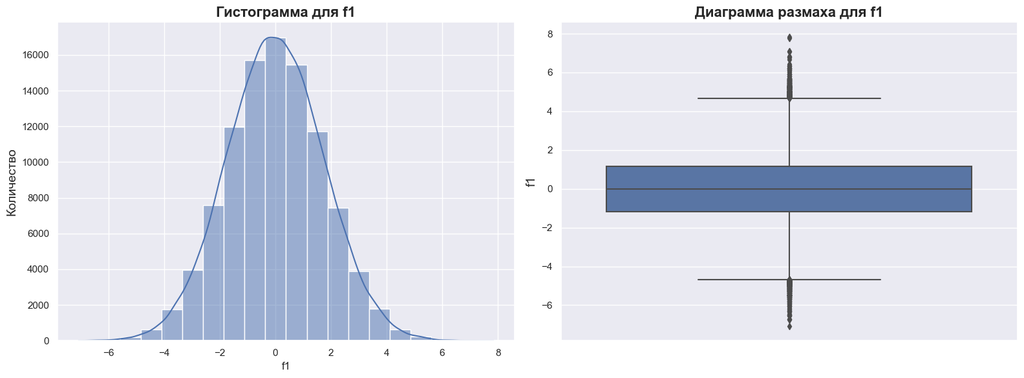

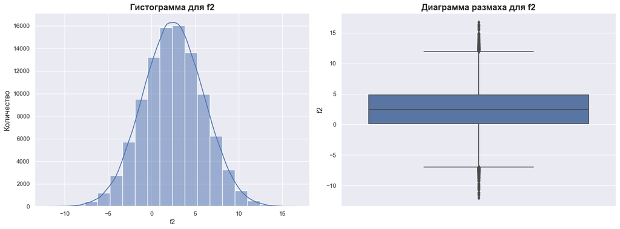

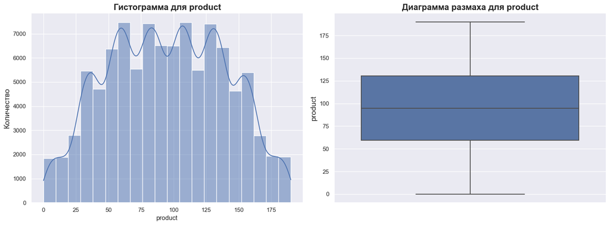

|  | f0 | f1 | f2 | product |
| --- | --- | --- | --- | --- |
| count | 100000.000000 | 100000.000000 | 100000.000000 | 100000.000000 |
| mean | 0.002023 | -0.002081 | 2.495128 | 95.000000 |
| std | 1.732045 | 1.730417 | 3.473445 | 44.749921 |
| min | -8.760004 | -7.084020 | -11.970335 | 0.000000 |
| 25% | -1.162288 | -1.174820 | 0.130359 | 59.450441 |
| 50% | 0.009424 | -0.009482 | 2.484236 | 94.925613 |
| 75% | 1.158535 | 1.163678 | 4.858794 | 130.595027 |
| max | 7.238262 | 7.844801 | 16.739402 | 190.029838 |

```python
# Формирование списка столбцов с количественными признаками
num_variables_col_2 = geo_data_2.select_dtypes(include=['number']).columns.to_list()

# Вывод графиков для датафрейма geo_data_2
for col in num_variables_col_2:
    show_num_variable(geo_data_2, col)

    print('=' * TERM_SIZE)

geo_data_2.describe()
```

- Параметр `f0` имеет распределение близкое к нормальному, в нем присутствуют выбросы. Mean ~ 0.002 и median ~ 0.009;
- Параметр `f1` имеет распределение близкое к нормальному, в нем присутствуют выбросы. Mean ~ -0.002 и median ~ -0.009;
- Параметр `f2` имеет распределение близкое к нормальному, в нем присутствуют выбросы. Mean ~ 2.495 и median ~ 2.484;
- Параметр `product` объем запасов в скважине имеет симметричное распределение относительно среднего, mean ~ 95 и median ~ 94.93.

**Анализ выбросов**

```python
print(show_outliers(geo_data_0, 'geo_data_0'))
print(show_outliers(geo_data_1, 'geo_data_1'))
print(show_outliers(geo_data_2, 'geo_data_2'))
```

```
Датафрейм: geo_data_0

Общий процент выбросов по строкам: 0.51%
Общее количество таких строк: 506

Датафрейм: geo_data_1

Общий процент выбросов по строкам: 0.64%
Общее количество таких строк: 637

Датафрейм: geo_data_2

Общий процент выбросов по строкам: 2.00%
Общее количество таких строк: 1996
```

Количество выбросов не превыает 1 % для датафреймов geo_data_0 и geo_data_1, а для датафрейма geo_data_2 кол-во выбросов состовляет 2%.

Эти выбросы могут содержать важную информацию, поэтому их удаление может повлиять на обученние модели МО. Например: цена продажи люксовых гиперкаров среди продаж всех машин на агрегаторе.

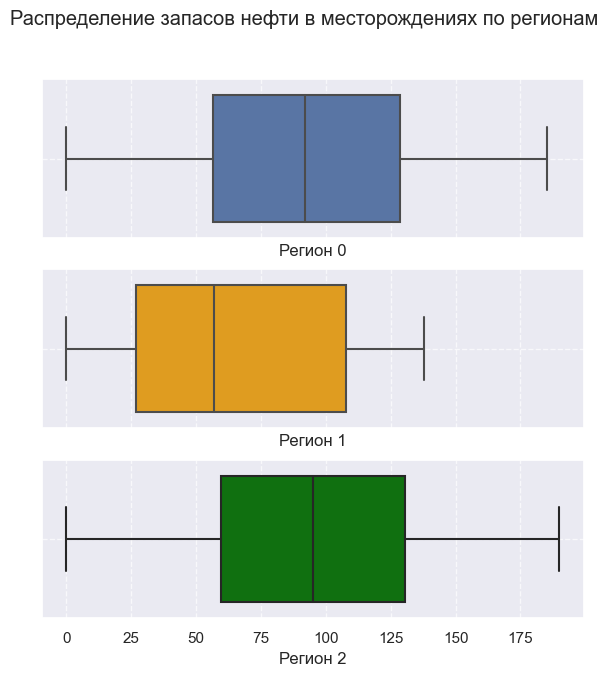

```python
# Создаём фигуру с 3 строками и 1 колонкой
fig, axes = plt.subplots(3, 1, sharex=True, figsize=(7,7))

# Строим боксплоты для каждого региона
sns.boxplot(geo_data_0['product'], ax=axes[0])
sns.boxplot(geo_data_1['product'], ax=axes[1], color='orange')
sns.boxplot(geo_data_2['product'], ax=axes[2], color='green')

# Добавляем сетку для всех графиков
for ax in axes:
    ax.grid(True, linestyle='--', alpha=0.7)

# Подписи для оси X
axes[0].set_xlabel('Регион 0')
axes[1].set_xlabel('Регион 1')
axes[2].set_xlabel('Регион 2')

# Заголовок для всей фигуры
fig.suptitle('Распределение запасов нефти в месторождениях по регионам')

# Показываем графики
plt.show()
```

```python
# Перебираем все датафреймы в словаре и выводим общий объем с порядковым номером
for i, (name, data) in enumerate(dataframes.items()):
    print(f"Общий объем запасов нефти по региону {i} = {data['product'].sum():.0f} тыс. баррелей")
```

```
Общий объем запасов нефти по региону 0 = 9250000 тыс. баррелей
Общий объем запасов нефти по региону 1 = 6882500 тыс. баррелей
Общий объем запасов нефти по региону 2 = 9500000 тыс. баррелей
```

### Корреляционный анализ

Для корреляционного анализа и впоследствии модели машинного обучения, признак `id` не нужен, т.к. не несет никакой смысловой нагрузки, а так же он может повлиять на итоговую модель.

```python
def corr_matrix_show(data, name='DataFrame'):
    """
    Функция строит матрицу корреляций с использованием phik для числовых и категориальных данных.

    Параметры:
    - data: pandas.DataFrame — входной датафрейм
    - name: str — название датафрейма для заголовка графика (по умолчанию 'DataFrame')

    Результат:
    - Тепловая карта корреляций с аннотациями
    """
    # Проверка наличия столбца 'id' и его удаление
    if 'id' in data.columns:
        data_without_id = data.drop('id', axis=1)
    else:
        data_without_id = data.copy()

    # Определяем числовые и категориальные столбцы
    num_cols = data_without_id.select_dtypes(include='number').columns.to_list()

    # Строим матрицу корреляций с учетом числовых и категориальных данных
    big_data_corr = data_without_id.phik_matrix(interval_cols=num_cols)

    # Визуализация матрицы корреляций
    plt.figure(figsize=(10, 6))
    sns.heatmap(big_data_corr, annot=True, fmt=".2f", center=0)
    plt.title(f'Матрица корреляций phik для {name}')
    plt.show()
```

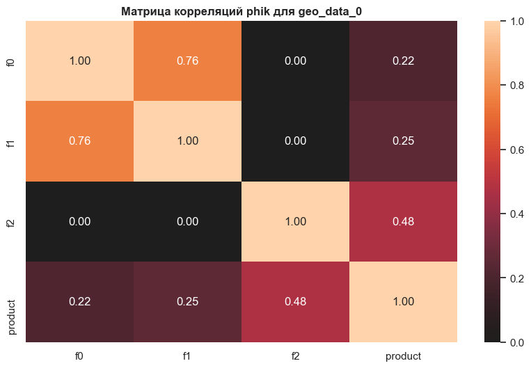

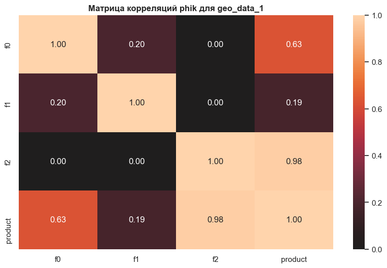

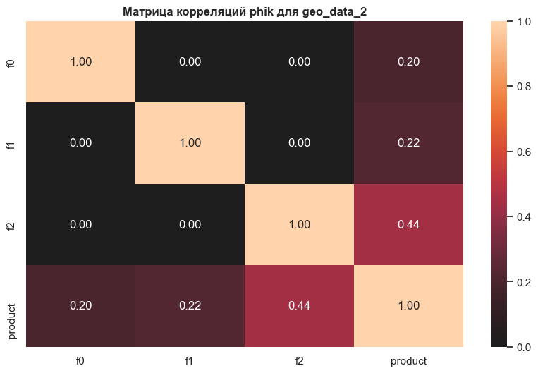

```python
for name, data in dataframes.items():
    corr_matrix_show(data, name)
    print('=' * TERM_SIZE)  # Линия-разделитель по ширине терминала
```

**Вывод по корреляционному анализу:**

В ходе анализа Phik матрицы корреляций были определены силы связи целевого признака `product` со входными, используя шкалу Чеддока:

Для датафрейма geo_data_0:

- **Умеренная связь** целевого признака прослеживается с входным признаком `f2` (0.48):
- **Слабая связь** целевого признака прослеживается с входными признаками `f0`, `f1` (0.22, 0.25);  
  Также наблюдается сильная связь между входными признаками `f0` и `f1` (0.76).

Для датафрейма geo_data_1:

- **Очень сильная связь** целевого признака прослеживается с входным признаком `f2` (0.98) - это может указывать, что этот признак сильный предиктор или на утечку целевого признака;
- **Сильная связь** целевого признака прослеживается с входным признаком `f0` (0.63);
- **Слабая связь** целевого признака прослеживается с входными признаками `f1` (0.19).

Для датафрейма geo_data_2:

- **Умеренная связь** целевого признака прослеживается с входным признаком `f2` (0.44):
- **Слабая связь** целевого признака прослеживается с входными признаками `f0`, `f1` (0.2, 0.22).

**Вывод по исследовательскому анализу:**

- Данные обладают незначительным количеством выбросов, для регионов №0 и №1 менее 1%, ддля региона №2 2%;
- В регионе №1 данные объемов запасов нефти категориальны, всего 12 видов значений;
- Лидируют по общим запасам нефти регионы №0 и №2.
- У датафрейма geo_data_1 наблюдается **очень сильная связь** целевого признака прослеживается с входным признаком `f2` (0.98), это нужно учитывать при обучении модели.

## Обучение и проверка моделей

Так как в данных присутствуют выбросы и была замечена связь между входными признаками, а по заданию нужно использовать толшько модели линейной регрессии, то также воспользуемся моделями линейной регрессии с регуляризациями:

- Lasso() - модель линейной регрессии с L1-регуляризацией;
- Ridge() - модель линейной регрессии с L2-регуляризацией.

Для обучиния 3-х моделей линейной регрессии для разных регионов, создадим и применим функцию

```python
def train_model_pipeline(data, name='DataFrame', test_size=TEST_SIZE, random_state=RANDOM_STATE):
    """
    Функция для обучения модели и подбора гиперпараметров с помощью GridSearchCV.

    Параметры:
    - data: DataFrame — исходные данные.
    - test_size: float — размер валидационной выборки.
    - random_state: int — фиксируем случайное состояние для воспроизводимости.

    Возвращает:
    - обученную модель
    - RMSE на валидационных данных
    - средние предсказанные и реальные значения целевого признака
    """
    # Подготовка данных
    X = data.drop(['product', 'id'], axis=1)
    y = data['product']

    # Разделение на train/valid
    X_train, X_valid, y_train, y_valid = train_test_split(
        X, y, test_size=test_size, random_state=random_state
    )

    scaler = ColumnTransformer(
    [
        ('num', MinMaxScaler(), X.columns)
    ],
    remainder='passthrough'
)

    # Пайплайн с масштабированием и моделью
    pipe = Pipeline([
        ('scaler', scaler),
        ('model', LinearRegression())
    ])

    # Сетка гиперпараметров
    param_grid = [
        {
            'model': [LinearRegression()],
            'scaler__num': [StandardScaler(), MinMaxScaler(), 'passthrough']
        },
        {
            'model': [Lasso()],
            'model__alpha': [0.01, 0.1, 1],
            'scaler__num': [StandardScaler(), MinMaxScaler(), 'passthrough']
        },
        {
            'model': [Ridge()],
            'model__alpha': [0.01, 0.1, 1],
            'scaler__num': [StandardScaler(), MinMaxScaler(), 'passthrough']
        }
    ]

    # Поиск лучших параметров
    grid_search = GridSearchCV(
        pipe,
        param_grid,
        n_jobs=-1,
        cv=5,
        scoring='neg_root_mean_squared_error'
    )
    grid_search.fit(X_train, y_train)

    # Вывод результатов
    print(f"Лучший результат RMSE: {-grid_search.best_score_:.2f}")
    print("Лучшие параметры:", grid_search.best_params_)

    # Оценка на валидации
    best_model = grid_search.best_estimator_
    y_pred = best_model.predict(X_valid)
    rmse = np.sqrt(mean_squared_error(y_valid, y_pred))

    stock_mean_pred = y_pred.mean()
    stock_mean = y.mean()

    y_valid = y_valid.reset_index(drop=True)

    print(f"✅ RMSE на валидационных данных: {rmse:.2f}")
    print(f"📌 Средний запас предсказанного сырья для региона {name}: {stock_mean_pred:.3f} тыс. баррелей")
    print(f"📌 Реальный средний запас сырья для региона {name}: {stock_mean:.3f} тыс. баррелей")


    # Выборка небольшого подмножества данных для ускорения
    X_train_sample = shap.sample(X_train, 500)
    X_valid_sample = shap.sample(X_valid, 500)

    # Преобразование данных через preprocessor для ускорения
    X_train_transformed = grid_search.best_estimator_['scaler'].fit_transform(X_train_sample)

    X_valid_transformed = grid_search.best_estimator_['scaler'].transform(X_valid_sample)

    # Получаем имена признаков после трансформации
    feature_names = grid_search.best_estimator_['scaler'].get_feature_names_out()

    # Создаем DataFrame для удобства анализа
    X_valid_enc = pd.DataFrame(X_valid_transformed, columns=feature_names)

    # Создание SHAP Explainer для модели SVR
    explainer = shap.PermutationExplainer(
        model=grid_search.best_estimator_['model'].predict,  # Предсказания через модель
        data=X_train_transformed,  # Преобразованные данные для обучения
        masker=shap.maskers.Independent(data=X_train_transformed)  # Указываем masker
    )

    # Расчёт SHAP-значений для тестового набора
    shap_values = explainer.shap_values(X_valid_transformed)

    # Преобразуем SHAP-значения в Explanation объект
    shap_values = shap.Explanation(
        values=shap_values,
        feature_names=feature_names,  # Имена признаков
        data=X_valid_transformed       # Исходные данные
    )

    # Визуализация важности признаков с подписями осей
    fig, ax = plt.subplots(figsize=(10, 6))  # Создаём фигуру и ось
    shap.plots.bar(shap_values, max_display=30, show=False)

    # Добавляем подписи осей
    ax.set_xlabel("Среднее абсолютное SHAP-значение", fontsize=12)
    ax.set_ylabel("Входные признаки", fontsize=12)
    ax.set_title("Важность признаков (SHAP)", fontsize=14, fontweight='bold')

    plt.show()  # Отображаем график

    return best_model, rmse, stock_mean_pred, stock_mean, y_pred, y_valid
```

```
Лучший результат RMSE: 37.67
Лучшие параметры: {'model': Ridge(), 'model__alpha': 0.1, 'scaler__num': MinMaxScaler()}
✅ RMSE на валидационных данных: 37.76
📌 Средний запас предсказанного сырья для региона №0: 92.399 тыс. баррелей
📌 Реальный средний запас сырья для региона №0: 92.500 тыс. баррелей
```

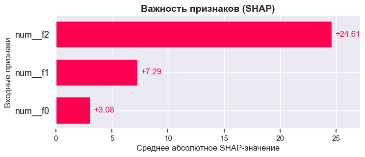

```python
best_model_0, rmse_0, stock_mean_pred_0, stock_mean_0, predictions_0, target_valid_0 = train_model_pipeline(geo_data_0, '№0')
```

```
Лучший результат RMSE: 0.89
Лучшие параметры: {'model': Ridge(), 'model__alpha': 0.01, 'scaler__num': StandardScaler()}
✅ RMSE на валидационных данных: 0.89
📌 Средний запас предсказанного сырья для региона №1: 68.713 тыс. баррелей
📌 Реальный средний запас сырья для региона №1: 68.825 тыс. баррелей
```

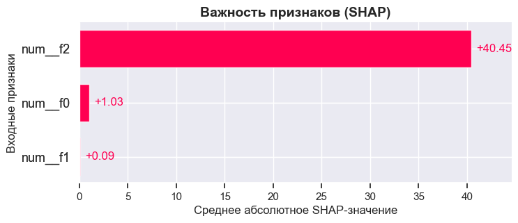

```python
best_model_1, rmse_1, stock_mean_pred_1, stock_mean_1, predictions_1, target_valid_1 = train_model_pipeline(geo_data_1, '№1')
```

```
Лучший результат RMSE: 40.03
Лучшие параметры: {'model': Lasso(), 'model__alpha': 0.1, 'scaler__num': StandardScaler()}
✅ RMSE на валидационных данных: 40.15
📌 Средний запас предсказанного сырья для региона №2: 94.772 тыс. баррелей
📌 Реальный средний запас сырья для региона №2: 95.000 тыс. баррелей
```

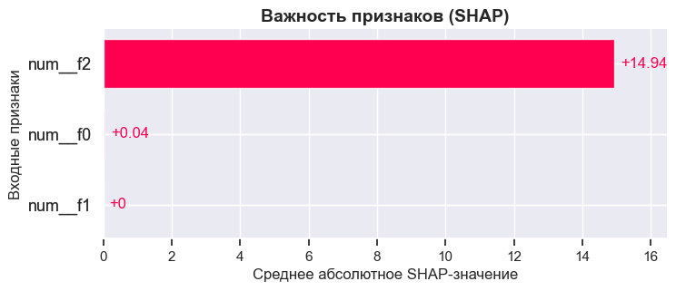

```python
best_model_2, rmse_2, stock_mean_pred_2, stock_mean_2, predictions_2, target_valid_2 = train_model_pipeline(geo_data_2, '№2')
```

Модель для региона №1:

- Модель для региона №1 ({'model': Ridge(), 'model__alpha': 0.01, 'scaler__num': StandardScaler()}) показала наилучший результат RMSE на валидационной выборке среди всех моделей = `0.89`, параметр наиболее сильно влияющий на запасы нефти `f2`, что подтверждает корреляционный анализ выявивший, что параметр `f2` имеет очень сильную линейную связь с целевым признаком;

Самые богатые регионы по запасам нефти - это регионы №0 и №2.

## Подготовка к расчёту прибыли

```python
budget = 10_000_000_000   #Бюджет
total_points = 500 #при разведке региона исследуют 500 точек
total_best_points = 200  # 200 лучших скважин
profit_per_unit = 450_000   # Доход с каждой единицы продукта 450 000 рублей
```

```python
required_volume_mean = budget / total_best_points / profit_per_unit
print(f"Средний объем сырья для безубыточной разработки новой скважины {required_volume_mean:.2f} тыс. баррелей")

required_volume_sum = budget / profit_per_unit
print(f"Общий объем сырья для безубыточной разработки в регионе {required_volume_sum:.2f} тыс. баррелей на {total_best_points} месторождений")
```

```
Средний объем сырья для безубыточной разработки новой скважины 111.11 тыс. баррелей
Общий объем сырья для безубыточной разработки в регионе 22222.22 тыс. баррелей на 200 месторождений
```

**Вывод:**

- Средний объем сырья для безубыточной разработки нефти в новой скважине 111.11 тыс. баррелей, что превышает среднее трех данных регионов, поэтому важно отбирать только хорошие скважины (топ 200).

## Функция для расчёта прибыли по выбранным скважинам и предсказаниям модели

```python
def profit(target, probabilities, count=200, profit_per_unit=profit_per_unit, budget=budget):
    """
    Расчет прибыли с учетом лучших объектов по предсказанным вероятностям.

    Параметры:
    - target: Series — реальные данные (например, запасы сырья).
    - probabilities: Series — предсказанные вероятности/запасы.
    - count: int — количество лучших объектов, которые отбираем.
    - profit_per_unit: float — прибыль с одной единицы продукции.
    - budget: float — общий бюджет на разработку месторождений.

    Возвращает:
    - profit_value: float — итоговая прибыль в млн. руб.
    """

    # Проверка, что длины target и probabilities совпадают
    assert len(target) == len(probabilities), "Длины target и probabilities должны совпадать!"

    # Проверка, что count не больше количества данных
    if count > len(probabilities):
        raise ValueError("count больше числа доступных данных!")

    # Сортировка вероятностей по убыванию и выбор лучших-count объектов
    sorted_indices = probabilities.argsort()[::-1]
    selected = target.iloc[sorted_indices[:count]]

    # Расчет прибыли
    profit_value = (profit_per_unit * selected.sum()) - budget

    return profit_value / 10**6
```

## Расчёт прибыли и рисков

```python
print(f"Прибыль региона №0: {profit(target_valid_0, pd.Series(predictions_0)):.2f} млн. рублей")
print(f"Прибыль региона №1: {profit(target_valid_1, pd.Series(predictions_1)):.2f} млн. рублей")
print(f"Прибыль региона №2: {profit(target_valid_2, pd.Series(predictions_2)):.2f} млн. рублей")
```

```
Прибыль региона №0: 3359.14 млн. рублей
Прибыль региона №1: 2415.09 млн. рублей
Прибыль региона №2: 2583.44 млн. рублей
```

```python
state = np.random.RandomState(12345)
def calc_bootstrap(target, probabilities, reg, N=1000):
    """
    Функция для расчета статистики Bootstrap для прибыли на основе предсказанных вероятностей и целевых значений.

    Параметры:
    -----------
    target : pd.Series
        Целевой признак (например, количество продукции) для анализа. Используется для расчета прибыли.

    probabilities : pd.Series
        Предсказанные вероятности или оценки, по которым выбираются лучшие объекты для расчета прибыли.
        Должен быть массив той же длины, что и target.

    reg : str
        Название региона (строка), которое будет выведено в отчете для каждого региона.

    N: int
        Кол-во выборок для bootstrap

    Возвращаемое значение:
    ----------------------
    Эта функция выводит статистику для региона:
    - Средняя прибыль (в миллионах рублей).
    - Доверительный интервал для средней прибыли (квантиль 2.5% и 97.5%).
    - 2.5%-квантиль (минимальная прибыль на основе выборки).
    - Вероятность убытка (доля итераций, где прибыль меньше 0).
    """
    values = []

    for i in range(N):  # Генерируем N случайных подвыборок
        target_subsample = target.sample(500, replace=True, random_state=state)

        probs_subsample = probabilities[target_subsample.index]

        # Вычисление прибыли для текущей подвыборки
        profit_value = profit(target_subsample, probs_subsample)
        values.append(profit_value)

    # Преобразуем значения в pandas Series
    values = pd.Series(values)

    # Расчет 95% доверительного интервала
    lower = values.quantile(0.025)  # 2.5%-квантиль
    upper = values.quantile(0.975)  # 97.5%-квантиль
    mean = values.mean()  # Среднее значение прибыли
    chance_loss = (values < 0).mean()  # Вероятность убытка (если прибыль меньше 0)

    # Вывод статистики
    print(reg)
    print(f"Средняя прибыль: {mean:.3f} млн. рублей")  # Средняя прибыль в миллионах
    print(f"95% доверительный интервал для средней прибыли: ({lower:.3f}, {upper:.3f}) млн. рублей")  # Доверительный интервал
    print(f"2.5%-квантиль: {lower:.3f} млн. рублей")  # 2.5%-квантиль
    print(f"Риск убытка: {chance_loss:.2%}\n")  # Риск убытка
```

```python
calc_bootstrap(target_valid_0, pd.Series(predictions_0), 'Регион №0')
calc_bootstrap(target_valid_1, pd.Series(predictions_1), 'Регион №1')
calc_bootstrap(target_valid_2, pd.Series(predictions_2), 'Регион №2')
```

```
Регион №0
Средняя прибыль: 406.310 млн. рублей
95% доверительный интервал для средней прибыли: (-117.742, 911.737) млн. рублей
2.5%-квантиль: -117.742 млн. рублей
Риск убытка: 6.70%

Регион №1
Средняя прибыль: 441.504 млн. рублей
95% доверительный интервал для средней прибыли: (35.728, 828.007) млн. рублей
2.5%-квантиль: 35.728 млн. рублей
Риск убытка: 1.60%

Регион №2
Средняя прибыль: 385.771 млн. рублей
95% доверительный интервал для средней прибыли: (-161.746, 887.952) млн. рублей
2.5%-квантиль: -161.746 млн. рублей
Риск убытка: 7.70%
```

**Вывод:**

- Регион №1, обладает наибольшей средней прибылью, а также вероятность убытков меньше 2.5%, что удовлетворяет поставленной задаче.

## Общий вывод:

1. Была выполнена загрузка данных в ходе которой получили общую информацию о датафреймах и определили отсутствие дубликатов;
2. Была выполнена предобработка данных в ходе которой была решена проблема с дубликатами;
3. Был проведен исследовательский анализ в ходе которого:
   - Получили информацию о кол-ве запасов нефти в каждом регионе: общий объем запасов нефти по региону 0 = 9250000 тыс. баррелей, общий объем запасов нефти по региону 1 = 6882500 тыс. баррелейо, общий объем запасов нефти по региону 2 = 9500000 тыс. баррелей;
   - Выявили наличие незначительных выбросов данных;
   - Провели корреляционный анализ, в ходе которого был обнаружен хороший предиктор для региона №1 (корреляция `f2` с целевым признаком `product` = 0.98).
4. Провели обучение и проверку 3-х моделей линейной регрессии для предсказания целевого параметра `product` - объём запасов нефти в скважине (тыс. баррелей):  
   Модель для региона №0:
   - Лучший результат RMSE: 37.67
   - Лучшие параметры: {'model': Ridge(), 'model__alpha': 0.1, 'scaler__num': MinMaxScaler()};
   - ✅ RMSE на валидационных данных: 37.76;
   - 📌 Средний запас предсказанного сырья для региона №0: 92.399 тыс. баррелей;
   - 📌 Реальный средний запас сырья для региона №0: 92.500 тыс. баррелей.  
     Модель для региона №1:
   - Лучший результат RMSE: 0.89;
   - Лучшие параметры: {'model': Ridge(), 'model__alpha': 0.01, 'scaler__num': StandardScaler()};
   - ✅ RMSE на валидационных данных: 0.89;
   - 📌 Средний запас предсказанного сырья для региона №1: 68.713 тыс. баррелей;
   - 📌 Реальный средний запас сырья для региона №1: 68.825 тыс. баррелей.  
     Модель для региона №2:
   - Лучший результат RMSE: 40.03;
   - Лучшие параметры: {'model': Lasso(), 'model__alpha': 0.1, 'scaler__num': StandardScaler()};
   - ✅ RMSE на валидационных данных: 40.15;
   - 📌 Средний запас предсказанного сырья для региона №2: 94.772 тыс. баррелей;
   - 📌 Реальный средний запас сырья для региона №2: 95.000 тыс. баррелей.  
     Лучшая модель по точности для региона №1.
5. Был проведен расчет прибыли и рисков добычи нефти в 200 лучших месторождениях для 3-х регионов, в результате которого с приминением метода бутстреп. В результате:
   - **Регион №0**  
     Средняя прибыль: 406.310 млн. рублей  
     95% доверительный интервал для средней прибыли: (-117.742, 911.737) млн. рублей  
     2.5%-квантиль: -117.742 млн. рублей  
     Риск убытка: 6.70%
   - **Регион №1**  
     Средняя прибыль: 441.504 млн. рублей  
     95% доверительный интервал для средней прибыли: (35.728, 828.007) млн. рублей  
     2.5%-квантиль: 35.728 млн. рублей  
     Риск убытка: 1.60%
   - **Регион №2**  
     Средняя прибыль: 385.771 млн. рублей  
     95% доверительный интервал для средней прибыли: (-161.746, 887.952) млн. рублей  
     2.5%-квантиль: -161.746 млн. рублей  
     Риск убытка: 7.70%  
     **Регион с наибольшей средней прибылью - Регион №1**